# Praktikum 1 MPDW

Atika Fawwaz G1401231038

2025-08-31

```r
# load library
library("forecast")
```

```r
library("graphics")
library("TTR")
library("TSA")
```

### Impor Data (baris 1-100)

```r
library(rio)
data <- import("https://raw.githubusercontent.com/atikafawwaz/mpdw/main/Pertemuan%201/coffeprices.xlsx", format = "xlsx")
```

### Eksplorasi Data

```r
View(data)
str(data)
```

```
## 'data.frame':    100 obs. of  2 variables:
##  $ Date : POSIXct, format: "1960-01-01" "1960-02-01" ...
##  $ Price: num  0.941 0.947 0.928 0.93 0.92 ...
```

```r
dim(data)
```

```
## [1] 100   2
```

```r
# konversi kolom Price menjadi objek time series
data.ts <- ts(data$Price, start = c(1960, 1), frequency = 12)
```

```r
summary(data.ts)
```

```
##    Min. 1st Qu.  Median    Mean 3rd Qu.    Max.
##  0.7970  0.8506  0.9001  0.9063  0.9546  1.0490
```

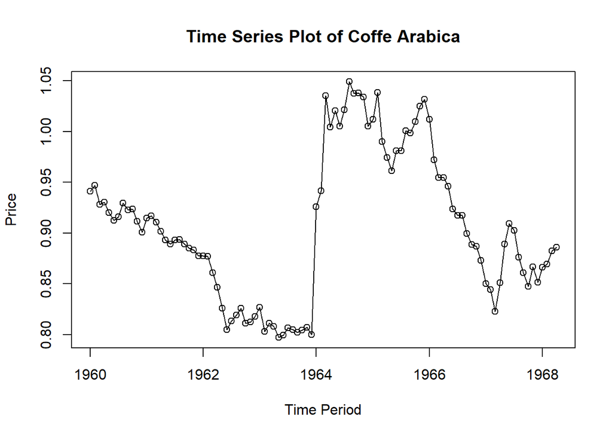

```r
# plot data deret waktu untuk melihat pola (trend/musiman)
ts.plot(data.ts, xlab="Time Period", ylab="Price",
        main = "Time Series Plot of Coffe Arabica")
points(data.ts)
```

### Pembagian Data

Pembagian data latih dan data uji dilakukan dengan perbandingan 80% data latih dan 20% data uji.

```r
# ubah kolom Date ke format Date
data$Date <- as.Date(data$Date, format = "%Y-%m-%d")

# split data
training_ma <- data[1:80,]
testing_ma  <- data[81:100,]

# ubah langsung jadi time series dengan periode asli
train_ma.ts <- ts(training_ma$Price,
                  start = c(as.numeric(format(training_ma$Date[1], "%Y")),
                            as.numeric(format(training_ma$Date[1], "%m"))),
                  frequency = 12)

test_ma.ts <- ts(testing_ma$Price,
                 start = c(as.numeric(format(testing_ma$Date[1], "%Y")),
                           as.numeric(format(testing_ma$Date[1], "%m"))),
                 frequency = 12)
```

### Eksplorasi Data

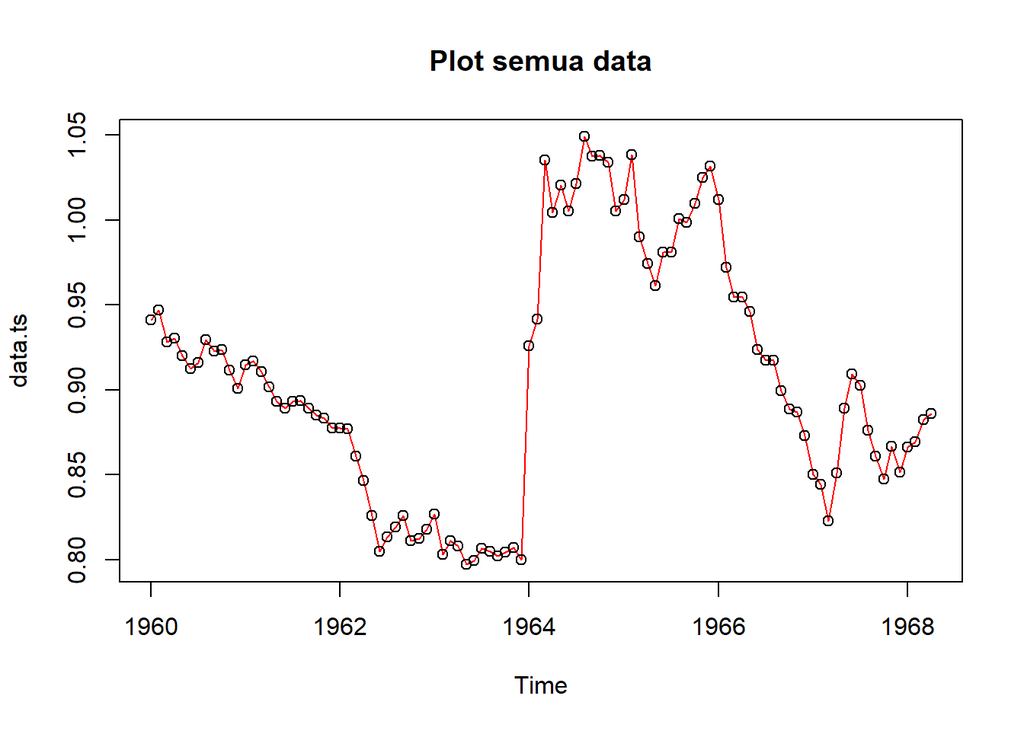

```r
#eksplorasi keseluruhan data
plot(data.ts, col="red",main="Plot semua data")
points(data.ts)
```

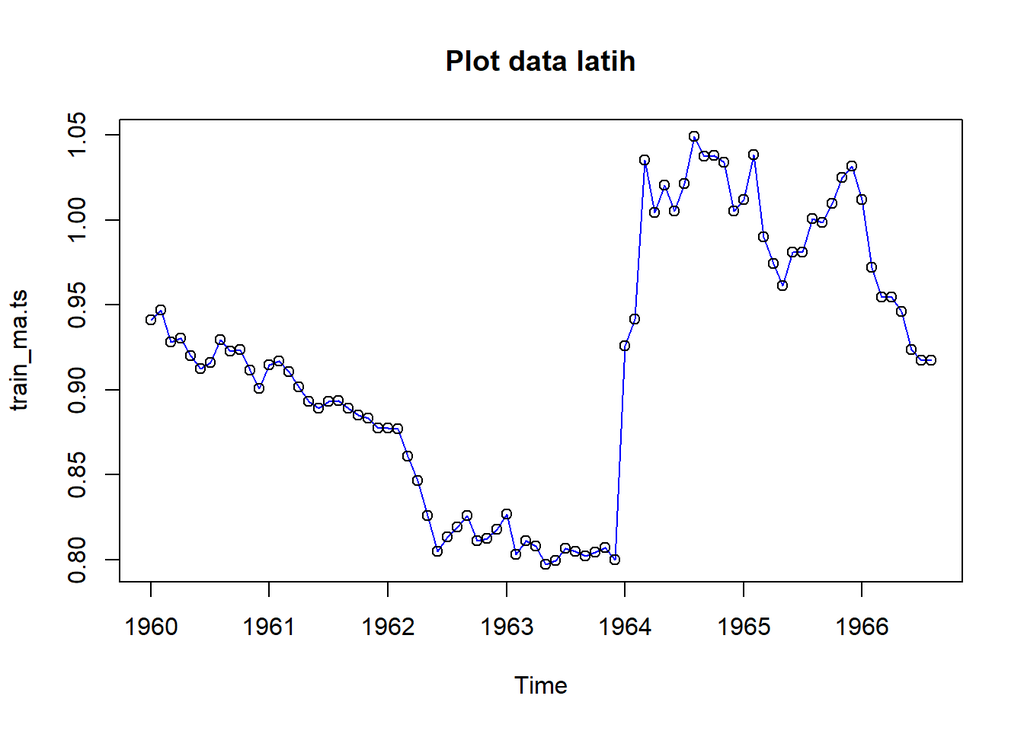

```r
#eksplorasi data latih
plot(train_ma.ts, col="blue",main="Plot data latih")
points(train_ma.ts)
```

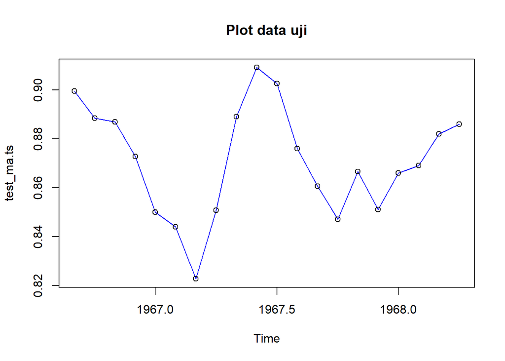

```r
#eksplorasi data uji
plot(test_ma.ts, col="blue",main="Plot data uji")
points(test_ma.ts)
```

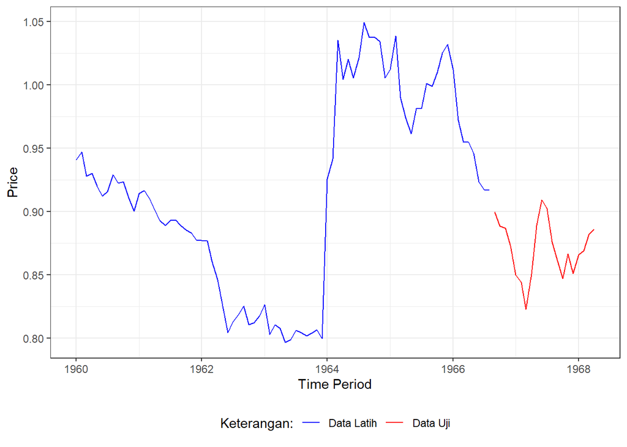

```r
#Eksplorasi dengan GGPLOT: bandingkan garis data latih vs data uji
library(ggplot2)
ggplot() +
  geom_line(data = training_ma, aes(x = Date, y = Price, col = "Data Latih")) +
  geom_line(data = testing_ma, aes(x = Date, y = Price, col = "Data Uji")) +
  labs(x = "Time Period", y = "Price", color = "Legend") +
  scale_colour_manual(name="Keterangan:", breaks = c("Data Latih", "Data Uji"),
                      values = c("blue", "red")) +
  theme_bw() + theme(legend.position = "bottom",
                     plot.caption = element_text(hjust=0.5, size=12))
```

Dari pola yang ada (lonjakan besar 1964, lalu turun lagi), penggunaan Double Moving Average (DMA) lebih disarankan karena bisa menangkap perubahan tren lebih cepat dibanding Single Moving Average (SMA).

## Double Moving Average

```r
data.sma<-SMA(train_ma.ts, n=4)
data.sma
```

```
##           Jan      Feb      Mar      Apr      May      Jun      Jul      Aug
## 1960       NA       NA       NA 0.936550 0.931325 0.922675 0.919650 0.919375
## 1961 0.912600 0.910850 0.910575 0.910850 0.905450 0.898550 0.894150 0.892100
## 1962 0.880750 0.878700 0.873175 0.865475 0.852525 0.834450 0.822500 0.815600
## 1963 0.816975 0.815025 0.814650 0.812175 0.804750 0.803775 0.802650 0.801825
## 1964 0.834200 0.868500 0.925550 0.976650 1.000250 1.016225 1.012800 1.024000
## 1965 1.022275 1.022400 1.011375 1.003650 0.990975 0.976650 0.974450 0.981075
## 1966 1.019625 1.010250 0.992625 0.973325 0.956800 0.944675 0.935300 0.925925
##           Sep      Oct      Nov      Dec
## 1960 0.920025 0.922875 0.921775 0.914625
## 1961 0.891150 0.890175 0.887700 0.883675
## 1962 0.815600 0.817150 0.816975 0.816700
## 1963 0.803075 0.804325 0.804450 0.803225
## 1964 1.028250 1.036400 1.039550 1.028625
## 1965 0.990450 0.997600 1.008600 1.016325
## 1966
```

```r
dma <- SMA(data.sma, n = 4)
At <- 2*data.sma - dma
Bt <- 2/(4-1)*(data.sma - dma)
data.dma<- At+Bt
data.ramal2<- c(NA, data.dma)

t = 1:24
f = c()

for (i in t) {
  f[i] = At[length(At)] + Bt[length(Bt)]*(i)
}

data.gab2 <- cbind(aktual = c(train_ma.ts,rep(NA,20)), pemulusan1 = c(data.sma,rep(NA,20)),pemulusan2 = c(data.dma, rep(NA,20)),At = c(At, rep(NA,20)), Bt = c(Bt,rep(NA,20)),ramalan = c(data.ramal2, f[-1]))
data.gab2
```

```
##        aktual pemulusan1 pemulusan2        At            Bt   ramalan
##   [1,] 0.9409         NA         NA        NA            NA        NA
##   [2,] 0.9469         NA         NA        NA            NA        NA
##   [3,] 0.9281         NA         NA        NA            NA        NA
##   [4,] 0.9303   0.936550         NA        NA            NA        NA
##   [5,] 0.9200   0.931325         NA        NA            NA        NA
##   [6,] 0.9123   0.922675         NA        NA            NA        NA
##   [7,] 0.9160   0.919650  0.9064833 0.9117500 -5.266667e-03        NA
##   [8,] 0.9292   0.919375  0.9129063 0.9154938 -2.587500e-03 0.9064833
##   [9,] 0.9226   0.920025  0.9193479 0.9196188 -2.708333e-04 0.9129063
##  [10,] 0.9237   0.922875  0.9268646 0.9252688  1.595833e-03 0.9193479
##  [11,] 0.9116   0.921775  0.9230458 0.9225375  5.083333e-04 0.9268646
##  [12,] 0.9006   0.914625  0.9059583 0.9094250 -3.466667e-03 0.9230458
##  [13,] 0.9145   0.912600  0.9036521 0.9072313 -3.579167e-03 0.9059583
##  [14,] 0.9167   0.910850  0.9039958 0.9067375 -2.741667e-03 0.9036521
```

[output cut: 90 more lines]

Hasil pemulusan menggunakan metode DMA divisualisasikan sebagai berikut

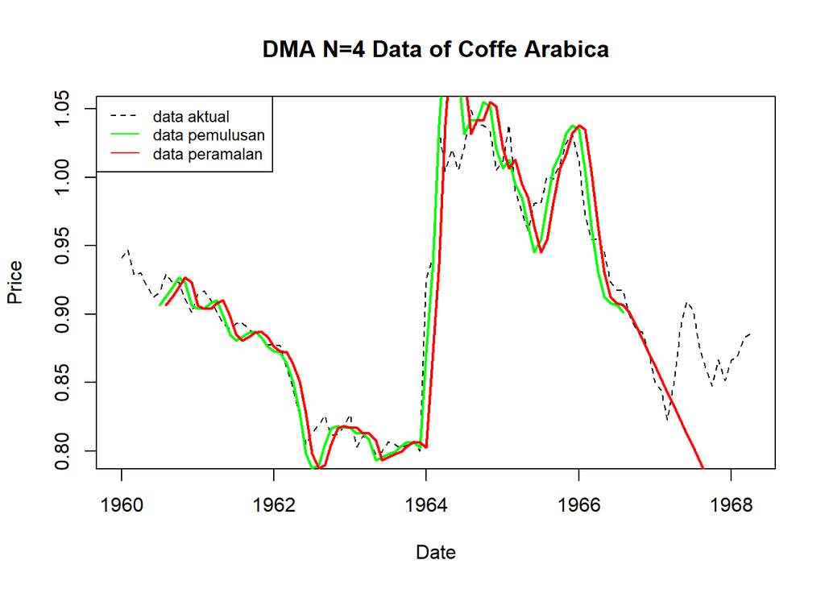

```r
# buat ts untuk kolom 3 (pemulusan) dan kolom 6 (ramalan)
pemulusan.ts <- ts(data.gab2[,3], start=c(1960,1), frequency=12)
ramalan.ts   <- ts(data.gab2[,6], start=c(1960,1), frequency=12)

# grafik dasar (data aktual)
ts.plot(data.ts,
        xlab="Date",
        ylab="Price",
        main="DMA N=4 Data of Coffe Arabica",
        col="black", lty=2)

# tambahkan garis pemulusan
lines(pemulusan.ts, col="green", lwd=2)

# tambahkan garis ramalan
lines(ramalan.ts, col="red", lwd=2)

# legenda
legend("topleft",
       legend=c("data aktual", "data pemulusan", "data peramalan"),
       col=c("black", "green", "red"),
       lty=c(2,1,1),
       cex=0.8)
```

Berdasarkan grafik DMA N=4, model pemulusan cukup mampu mengikuti pola pergerakan harga kopi arabika 1960–1967. Hasil peramalan menunjukkan tren menurun setelah 1967, yang mencerminkan keterbatasan metode DMA dalam menangkap pola musiman. Selanjutnya perhitungan akurasi dilakukan baik pada data latih maupun data uji. Perhitungan akurasi dilakukan dengan ukuran akurasi SSE, MSE dan MAPE.

```r
#Menghitung nilai keakuratan data latih
error_train.dma = train_ma.ts-data.ramal2[1:length(train_ma.ts)]
SSE_train.dma = sum(error_train.dma[8:length(train_ma.ts)]^2)
MSE_train.dma = mean(error_train.dma[8:length(train_ma.ts)]^2)
MAPE_train.dma = mean(abs((error_train.dma[8:length(train_ma.ts)]/train_ma.ts[8:length(train_ma.ts)])*100))

akurasi_train.dma <- matrix(c(SSE_train.dma, MSE_train.dma, MAPE_train.dma))
row.names(akurasi_train.dma)<- c("SSE", "MSE", "MAPE")
colnames(akurasi_train.dma) <- c("Akurasi m = 4")
akurasi_train.dma
```

```
##      Akurasi m = 4
## SSE    0.073704080
## MSE    0.001009645
## MAPE   2.176682883
```

Perhitungan akurasi pada data latih menggunakan nilai MAPE sebesar 2.18% (kurang dari 10%) sehingga dikategorikan sangat baik. Selanjutnya, perhitungan nilai akurasi dilakukan pada data uji.

```r
#Menghitung nilai keakuratan data uji
error_test.dma = test_ma.ts-data.gab2[81:100,6]
SSE_test.dma = sum(error_test.dma^2)
MSE_test.dma = mean(error_test.dma^2)
MAPE_test.dma = mean(abs((error_test.dma/test_ma.ts*100)))

akurasi_test.dma <- matrix(c(SSE_test.dma, MSE_test.dma, MAPE_test.dma))
row.names(akurasi_test.dma)<- c("SSE", "MSE", "MAPE")
colnames(akurasi_test.dma) <- c("Akurasi m = 4")
akurasi_test.dma
```

```
##      Akurasi m = 4
## SSE    0.150327181
## MSE    0.007516359
## MAPE   7.727265790
```

## Single Exponential Smoothing & Double Exponential Smoothing

### Pembagian Data

```r
#membagi training dan testing
# ubah kolom Date ke format Date
data$Date <- as.Date(data$Date)

# split data
training <- data[1:80,]
testing  <- data[81:100,]

# langsung buat time series dengan format base R
train.ts <- ts(training$Price,
               start = c(as.numeric(format(training$Date[1], "%Y")),
                         as.numeric(format(training$Date[1], "%m"))),
               frequency = 12)

test.ts <- ts(testing$Price,
              start = c(as.numeric(format(testing$Date[1], "%Y")),
                        as.numeric(format(testing$Date[1], "%m"))),
              frequency = 12)
```

### SES

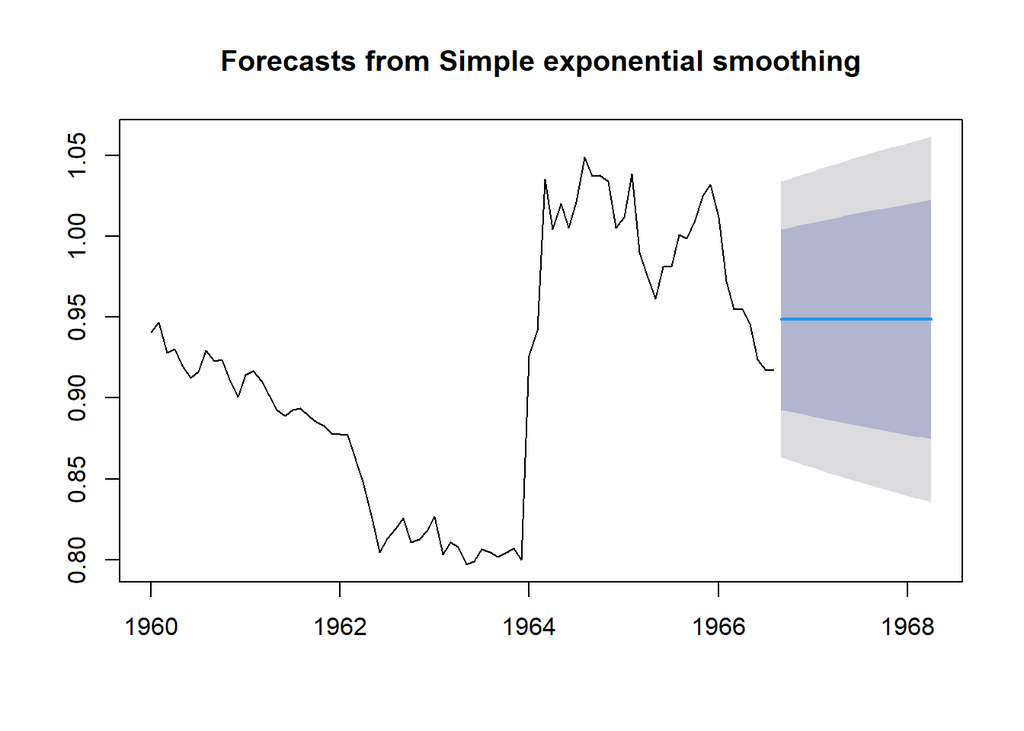

```r
#Cara 1 (fungsi single exponential smoothing dengan alpha 0.2 dan 0.7)
ses.1 <- ses(train.ts, h = 20, alpha = 0.2)
plot(ses.1)
```

```r
ses.1
```

```
##          Point Forecast     Lo 80    Hi 80     Lo 95    Hi 95
## Sep 1966      0.9485411 0.8928698 1.004212 0.8633992 1.033683
## Oct 1966      0.9485411 0.8917673 1.005315 0.8617131 1.035369
## Nov 1966      0.9485411 0.8906858 1.006396 0.8600590 1.037023
## Dec 1966      0.9485411 0.8896241 1.007458 0.8584354 1.038647
## Jan 1967      0.9485411 0.8885813 1.008501 0.8568405 1.040242
## Feb 1967      0.9485411 0.8875563 1.009526 0.8552728 1.041809
## Mar 1967      0.9485411 0.8865482 1.010534 0.8537311 1.043351
## Apr 1967      0.9485411 0.8855562 1.011526 0.8522140 1.044868
## May 1967      0.9485411 0.8845797 1.012503 0.8507205 1.046362
## Jun 1967      0.9485411 0.8836178 1.013465 0.8492494 1.047833
## Jul 1967      0.9485411 0.8826699 1.014412 0.8477998 1.049282
## Aug 1967      0.9485411 0.8817355 1.015347 0.8463708 1.050711
## Sep 1967      0.9485411 0.8808140 1.016268 0.8449615 1.052121
## Oct 1967      0.9485411 0.8799049 1.017177 0.8435711 1.053511
## Nov 1967      0.9485411 0.8790077 1.018075 0.8421989 1.054883
## Dec 1967      0.9485411 0.8781219 1.018960 0.8408441 1.056238
## Jan 1968      0.9485411 0.8772471 1.019835 0.8395062 1.057576
## Feb 1968      0.9485411 0.8763829 1.020699 0.8381846 1.058898
## Mar 1968      0.9485411 0.8755289 1.021553 0.8368785 1.060204
## Apr 1968      0.9485411 0.8746848 1.022398 0.8355876 1.061495
```

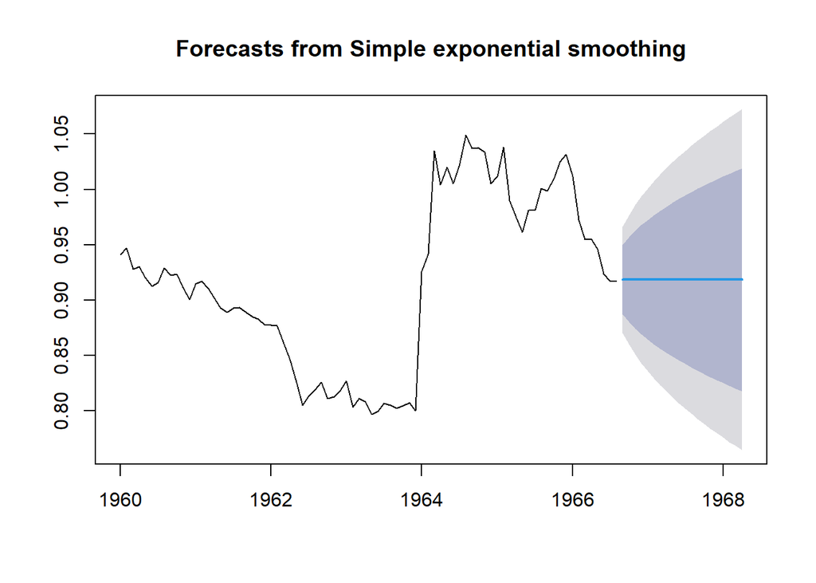

```r
ses.2<- ses(train.ts, h = 20, alpha = 0.7)
plot(ses.2)
```

```r
ses.2
```

```
##          Point Forecast     Lo 80     Hi 80     Lo 95     Hi 95
## Sep 1966      0.9183846 0.8869963 0.9497728 0.8703804 0.9663887
## Oct 1966      0.9183846 0.8800703 0.9566988 0.8597880 0.9769811
## Nov 1966      0.9183846 0.8742174 0.9625517 0.8508367 0.9859324
## Dec 1966      0.9183846 0.8690541 0.9677150 0.8429401 0.9938290
## Jan 1967      0.9183846 0.8643822 0.9723869 0.8357951 1.0009740
## Feb 1967      0.9183846 0.8600835 0.9766856 0.8292208 1.0075483
## Mar 1967      0.9183846 0.8560807 0.9806884 0.8230990 1.0136701
## Apr 1967      0.9183846 0.8523200 0.9844491 0.8173475 1.0194216
## May 1967      0.9183846 0.8487621 0.9880070 0.8119062 1.0248629
## Jun 1967      0.9183846 0.8453774 0.9913917 0.8067297 1.0300394
## Jul 1967      0.9183846 0.8421428 0.9946263 0.8017829 1.0349863
## Aug 1967      0.9183846 0.8390400 0.9977291 0.7970375 1.0397316
## Sep 1967      0.9183846 0.8360540 1.0007151 0.7924708 1.0442983
## Oct 1967      0.9183846 0.8331726 1.0035965 0.7880641 1.0487050
## Nov 1967      0.9183846 0.8303855 1.0063836 0.7838016 1.0529675
## Dec 1967      0.9183846 0.8276840 1.0090851 0.7796700 1.0570991
## Jan 1968      0.9183846 0.8250606 1.0117085 0.7756579 1.0611112
## Feb 1968      0.9183846 0.8225090 1.0142601 0.7717556 1.0650135
## Mar 1968      0.9183846 0.8200236 1.0167455 0.7679545 1.0688146
## Apr 1968      0.9183846 0.8175995 1.0191696 0.7642471 1.0725220
```

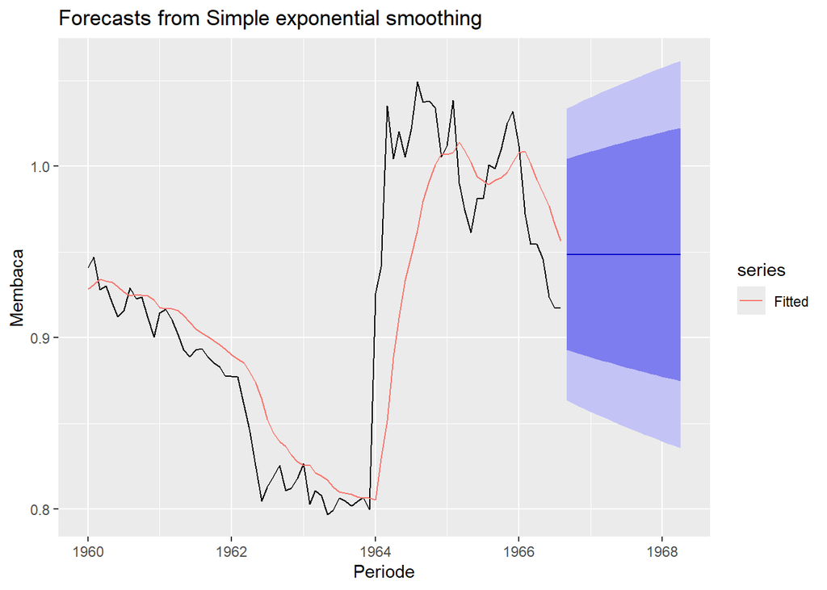

```r
# visualisasi hasil SES
autoplot(ses.1) +
  autolayer(fitted(ses.1), series="Fitted") +
  ylab("Membaca") + xlab("Periode")
```

SES menghasilkan ramalan yang terlalu sederhana (datar), sehingga kurang realistis untuk data dengan volatilitas tinggi. Namun, SES tetap bermanfaat sebagai model pembanding dasar, sebelum menggunakan metode yang lebih kompleks (misalnya Holt-Winters atau ARIMA).

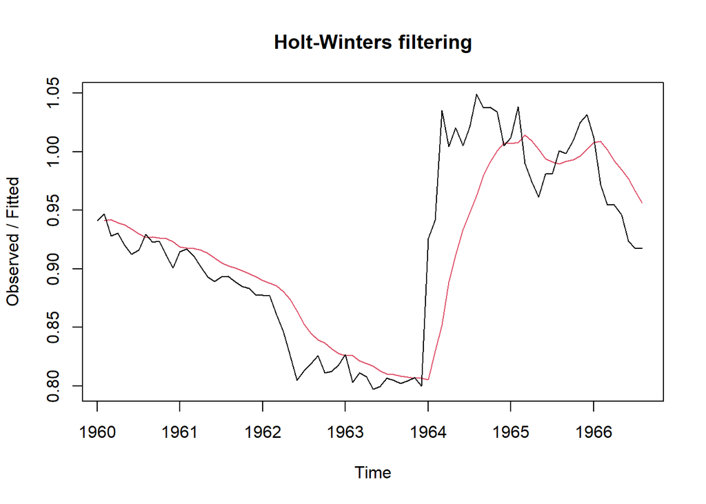

```r
#Cara 2 (fungsi Holtwinter)
ses1<- HoltWinters(train.ts, gamma = FALSE, beta = FALSE, alpha = 0.2)
plot(ses1)
```

```r
#ramalan
ramalan1<- forecast(ses1, h=20)
ramalan1
```

```
##          Point Forecast     Lo 80    Hi 80     Lo 95    Hi 95
## Sep 1966      0.9485411 0.8927932 1.004289 0.8632820 1.033800
## Oct 1966      0.9485411 0.8916892 1.005393 0.8615936 1.035489
## Nov 1966      0.9485411 0.8906062 1.006476 0.8599373 1.037145
## Dec 1966      0.9485411 0.8895431 1.007539 0.8583114 1.038771
## Jan 1967      0.9485411 0.8884988 1.008584 0.8567143 1.040368
## Feb 1967      0.9485411 0.8874723 1.009610 0.8551445 1.041938
## Mar 1967      0.9485411 0.8864629 1.010619 0.8536006 1.043482
## Apr 1967      0.9485411 0.8854695 1.011613 0.8520815 1.045001
## May 1967      0.9485411 0.8844916 1.012591 0.8505859 1.046496
## Jun 1967      0.9485411 0.8835284 1.013554 0.8491128 1.047970
## Jul 1967      0.9485411 0.8825793 1.014503 0.8476612 1.049421
## Aug 1967      0.9485411 0.8816436 1.015439 0.8462302 1.050852
## Sep 1967      0.9485411 0.8807208 1.016361 0.8448190 1.052263
## Oct 1967      0.9485411 0.8798105 1.017272 0.8434266 1.053656
## Nov 1967      0.9485411 0.8789120 1.018170 0.8420525 1.055030
## Dec 1967      0.9485411 0.8780250 1.019057 0.8406959 1.056386
## Jan 1968      0.9485411 0.8771489 1.019933 0.8393562 1.057726
## Feb 1968      0.9485411 0.8762836 1.020799 0.8380327 1.059050
## Mar 1968      0.9485411 0.8754284 1.021654 0.8367249 1.060357
## Apr 1968      0.9485411 0.8745831 1.022499 0.8354321 1.061650
```

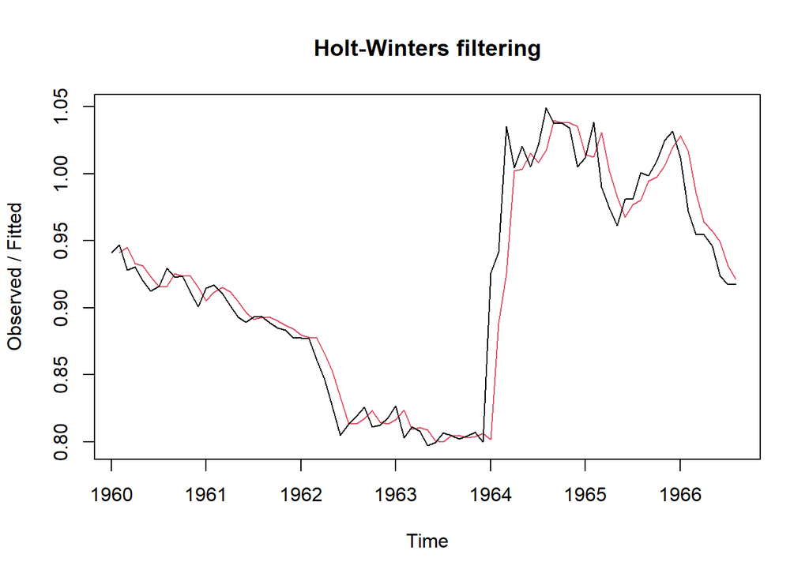

```r
ses2<- HoltWinters(train.ts, gamma = FALSE, beta = FALSE, alpha = 0.7)
plot(ses2)
```

```r
#ramalan
ramalan2<- forecast(ses2, h=20)
ramalan2
```

```
##          Point Forecast     Lo 80     Hi 80     Lo 95     Hi 95
## Sep 1966      0.9183846 0.8870007 0.9497684 0.8703871 0.9663820
## Oct 1966      0.9183846 0.8800757 0.9566934 0.8597962 0.9769729
## Nov 1966      0.9183846 0.8742236 0.9625455 0.8508462 0.9859229
## Dec 1966      0.9183846 0.8690610 0.9677081 0.8429507 0.9938185
## Jan 1967      0.9183846 0.8643898 0.9723794 0.8358066 1.0009625
## Feb 1967      0.9183846 0.8600917 0.9766775 0.8292333 1.0075358
## Mar 1967      0.9183846 0.8560894 0.9806797 0.8231123 1.0136568
## Apr 1967      0.9183846 0.8523292 0.9844399 0.8173616 1.0194075
## May 1967      0.9183846 0.8487718 0.9879973 0.8119211 1.0248480
## Jun 1967      0.9183846 0.8453876 0.9913815 0.8067453 1.0300238
## Jul 1967      0.9183846 0.8421535 0.9946156 0.8017992 1.0349699
## Aug 1967      0.9183846 0.8390511 0.9977180 0.7970545 1.0397146
## Sep 1967      0.9183846 0.8360655 1.0007036 0.7924884 1.0442807
## Oct 1967      0.9183846 0.8331845 1.0035846 0.7880823 1.0486868
## Nov 1967      0.9183846 0.8303978 1.0063713 0.7838204 1.0529487
## Dec 1967      0.9183846 0.8276967 1.0090725 0.7796894 1.0570797
## Jan 1968      0.9183846 0.8250737 1.0116954 0.7756779 1.0610912
## Feb 1968      0.9183846 0.8225225 1.0142467 0.7717761 1.0649930
## Mar 1968      0.9183846 0.8200374 1.0167317 0.7679755 1.0687936
## Apr 1968      0.9183846 0.8176136 1.0191555 0.7642687 1.0725005
```

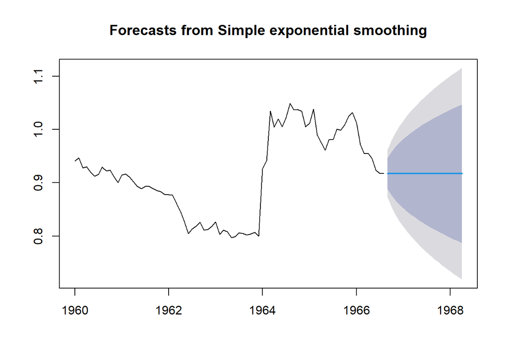

```r
#SES
ses.opt <- ses(train.ts, h = 20, alpha = NULL)
plot(ses.opt)
```

```r
ses.opt
```

```
##          Point Forecast     Lo 80     Hi 80     Lo 95     Hi 95
## Sep 1966         0.9171 0.8880055 0.9461945 0.8726039 0.9615961
## Oct 1966         0.9171 0.8759563 0.9582437 0.8541761 0.9800239
## Nov 1966         0.9171 0.8667103 0.9674897 0.8400356 0.9941644
## Dec 1966         0.9171 0.8589155 0.9752845 0.8281144 1.0060856
## Jan 1967         0.9171 0.8520481 0.9821519 0.8176116 1.0165884
## Feb 1967         0.9171 0.8458394 0.9883606 0.8081163 1.0260837
## Mar 1967         0.9171 0.8401299 0.9940701 0.7993844 1.0348156
## Apr 1967         0.9171 0.8348157 0.9993843 0.7912570 1.0429430
## May 1967         0.9171 0.8298244 1.0043756 0.7836235 1.0505765
## Jun 1967         0.9171 0.8251036 1.0090964 0.7764036 1.0577964
## Jul 1967         0.9171 0.8206134 1.0135866 0.7695365 1.0646635
## Aug 1967         0.9171 0.8163231 1.0178769 0.7629751 1.0712249
## Sep 1967         0.9171 0.8122082 1.0219918 0.7566818 1.0775182
## Oct 1967         0.9171 0.8082487 1.0259513 0.7506263 1.0835737
## Nov 1967         0.9171 0.8044282 1.0297718 0.7447834 1.0894166
## Dec 1967         0.9171 0.8007331 1.0334669 0.7391323 1.0950677
## Jan 1968         0.9171 0.7971518 1.0370482 0.7336551 1.1005449
## Feb 1968         0.9171 0.7936744 1.0405256 0.7283368 1.1058632
## Mar 1968         0.9171 0.7902923 1.0439077 0.7231643 1.1110357
## Apr 1968         0.9171 0.7869981 1.0472019 0.7181263 1.1160737
```

```r
#Lamda Optimum Holt Winter
sesopt<- HoltWinters(train.ts, gamma = FALSE, beta = FALSE,alpha = NULL)
sesopt
```

```
## Holt-Winters exponential smoothing without trend and without seasonal component.
##
## Call:
## HoltWinters(x = train.ts, alpha = NULL, beta = FALSE, gamma = FALSE)
##
## Smoothing parameters:
##  alpha: 0.9999207
##  beta : FALSE
##  gamma: FALSE
##
## Coefficients:
##     [,1]
## a 0.9171
```

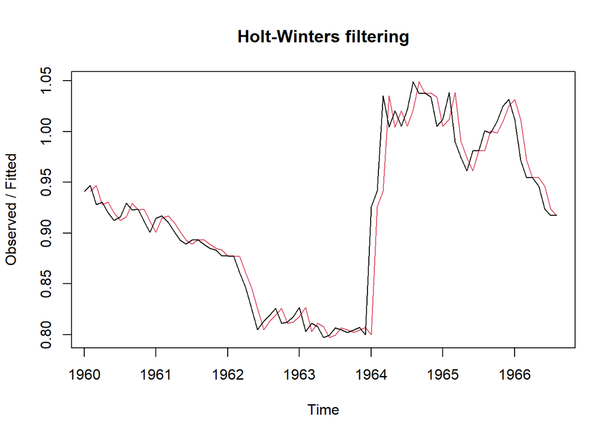

```r
plot(sesopt)
```

```r
#ramalan
ramalanopt<- forecast(sesopt, h=20)
ramalanopt
```

```
##          Point Forecast     Lo 80     Hi 80     Lo 95     Hi 95
## Sep 1966         0.9171 0.8880082 0.9461918 0.8726079 0.9615921
## Oct 1966         0.9171 0.8759595 0.9582405 0.8541811 0.9800189
## Nov 1966         0.9171 0.8667141 0.9674859 0.8400414 0.9941586
## Dec 1966         0.9171 0.8589198 0.9752802 0.8281210 1.0060790
## Jan 1967         0.9171 0.8520528 0.9821472 0.8176189 1.0165811
## Feb 1967         0.9171 0.8458445 0.9883555 0.8081242 1.0260758
## Mar 1967         0.9171 0.8401354 0.9940646 0.7993929 1.0348071
## Apr 1967         0.9171 0.8348215 0.9993785 0.7912659 1.0429341
## May 1967         0.9171 0.8298306 1.0043694 0.7836330 1.0505670
## Jun 1967         0.9171 0.8251101 1.0090899 0.7764135 1.0577865
## Jul 1967         0.9171 0.8206202 1.0135798 0.7695469 1.0646531
## Aug 1967         0.9171 0.8163302 1.0178698 0.7629859 1.0712141
## Sep 1967         0.9171 0.8122155 1.0219845 0.7566930 1.0775070
## Oct 1967         0.9171 0.8082563 1.0259437 0.7506379 1.0835621
## Nov 1967         0.9171 0.8044361 1.0297639 0.7447954 1.0894046
## Dec 1967         0.9171 0.8007413 1.0334587 0.7391447 1.0950553
## Jan 1968         0.9171 0.7971602 1.0370398 0.7336679 1.1005321
## Feb 1968         0.9171 0.7936830 1.0405170 0.7283500 1.1058500
## Mar 1968         0.9171 0.7903011 1.0438989 0.7231778 1.1110222
## Apr 1968         0.9171 0.7870071 1.0471929 0.7181401 1.1160599
```

Dengan alpha = 0.2, pemulusan lebih kuat sehingga fitted line lebih halus dan menolak fluktuasi sementara, namun tertinggal saat ada lonjakan tajam. Dengan alpha = 0.7, model lebih responsif dan fitted line menempel pada data aktual, tetapi juga lebih peka terhadap noise.

### DES

Metode pemulusan *Double Exponential Smoothing* (DES) digunakan untuk data yang memiliki pola tren. Pemulusan menggunakan metode ini akan menghasilkan peramalan tidak konstan untuk periode berikutnya.

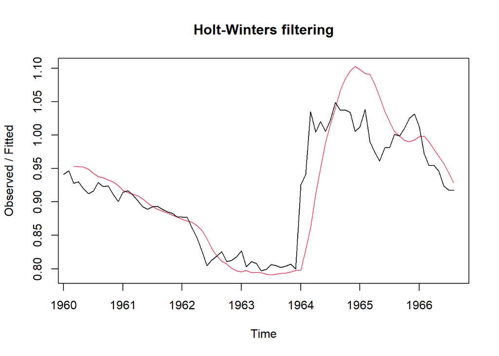

```r
#Lamda=0.2 dan gamma=0.2
des.1<- HoltWinters(train.ts, gamma = FALSE, beta = 0.2, alpha = 0.2)
plot(des.1)
```

```r
#ramalan
ramalandes1<- forecast(des.1, h=20)
ramalandes1
```

```
##          Point Forecast     Lo 80     Hi 80     Lo 95     Hi 95
## Sep 1966      0.9170801 0.8600630 0.9740971 0.8298800 1.0042801
## Oct 1966      0.9078087 0.8491726 0.9664449 0.8181325 0.9974850
## Nov 1966      0.8985374 0.8377668 0.9593081 0.8055967 0.9914781
## Dec 1966      0.8892661 0.8258156 0.9527166 0.7922269 0.9863053
## Jan 1967      0.8799948 0.8133068 0.9466828 0.7780043 0.9819853
## Feb 1967      0.8707235 0.8002434 0.9412036 0.7629335 0.9785135
## Mar 1967      0.8614522 0.7866402 0.9362641 0.7470372 0.9758671
## Apr 1967      0.8521808 0.7725200 0.9318416 0.7303502 0.9740115
## May 1967      0.8429095 0.7579101 0.9279089 0.7129142 0.9729049
## Jun 1967      0.8336382 0.7428396 0.9244368 0.6947737 0.9725027
## Jul 1967      0.8243669 0.7273373 0.9213964 0.6759730 0.9727608
## Aug 1967      0.8150956 0.7114311 0.9187600 0.6565545 0.9736367
## Sep 1967      0.8058242 0.6951465 0.9165020 0.6365573 0.9750912
## Oct 1967      0.7965529 0.6785070 0.9145989 0.6160172 0.9770886
## Nov 1967      0.7872816 0.6615335 0.9130297 0.5949665 0.9795968
## Dec 1967      0.7780103 0.6442448 0.9117757 0.5734337 0.9825869
## Jan 1968      0.7687390 0.6266578 0.9108202 0.5514446 0.9860334
## Feb 1968      0.7594677 0.6087872 0.9101481 0.5290218 0.9899135
## Mar 1968      0.7501963 0.5906464 0.9097463 0.5061857 0.9942070
## Apr 1968      0.7409250 0.5722470 0.9096030 0.4829543 0.9988957
```

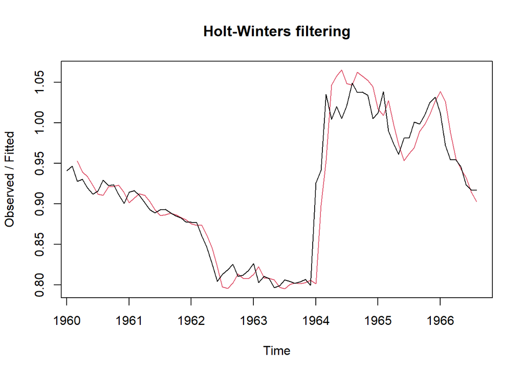

```r
#Lamda=0.6 dan gamma=0.3
des.2<- HoltWinters(train.ts, gamma = FALSE, beta = 0.3, alpha = 0.6)
plot(des.2)
```

```r
#ramalan
ramalandes2<- forecast(des.2, h=20)
ramalandes2
```

```
##          Point Forecast     Lo 80     Hi 80     Lo 95     Hi 95
## Sep 1966      0.9012217 0.8683675 0.9340758 0.8509756 0.9514677
## Oct 1966      0.8909437 0.8492771 0.9326102 0.8272202 0.9546671
## Nov 1966      0.8806656 0.8284079 0.9329233 0.8007444 0.9605869
## Dec 1966      0.8703876 0.8060942 0.9346811 0.7720593 0.9687160
## Jan 1967      0.8601096 0.7825571 0.9376621 0.7415033 0.9787159
## Feb 1967      0.8498316 0.7579457 0.9417175 0.7093042 0.9903590
## Mar 1967      0.8395536 0.7323644 0.9467427 0.6756220 1.0034852
## Apr 1967      0.8292755 0.7058909 0.9526602 0.6405750 1.0179761
## May 1967      0.8189975 0.6785846 0.9594104 0.6042545 1.0337405
## Jun 1967      0.8087195 0.6504935 0.9669455 0.5667337 1.0507053
## Jul 1967      0.7984415 0.6216569 0.9752261 0.5280728 1.0688102
## Aug 1967      0.7881635 0.5921082 0.9842187 0.4883228 1.0880041
## Sep 1967      0.7778854 0.5618760 0.9938949 0.4475276 1.1082433
## Oct 1967      0.7676074 0.5309855 1.0042293 0.4057255 1.1294894
## Nov 1967      0.7573294 0.4994589 1.0151999 0.3629506 1.1517083
## Dec 1967      0.7470514 0.4673162 1.0267866 0.3192333 1.1748695
## Jan 1968      0.7367734 0.4345753 1.0389715 0.2746013 1.1989455
## Feb 1968      0.7264954 0.4012526 1.0517381 0.2290796 1.2239111
## Mar 1968      0.7162173 0.3673633 1.0650714 0.1826911 1.2497435
## Apr 1968      0.7059393 0.3329211 1.0789575 0.1354572 1.2764214
```

Grafik 1 (α=0.2, β=0.2): Lebih halus, lebih stabil, tapi kurang responsif.

Grafik 2 (α=0.6, β=0.3): Lebih responsif, fitted lebih dekat ke data aktual, tapi juga lebih sensitif terhadap noise.

Selanjutnya jika ingin membandingkan plot data latih dan data uji adalah sebagai berikut.

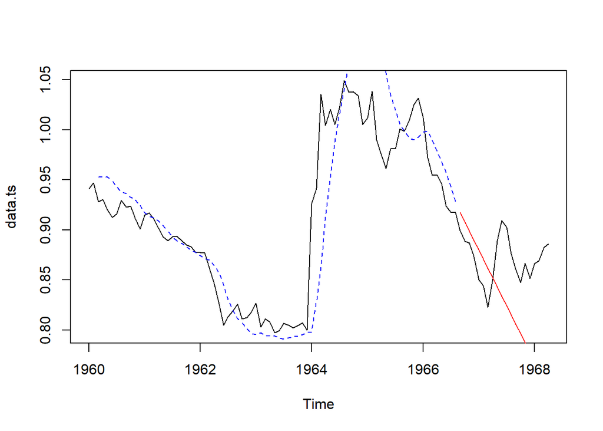

```r
#Visually evaluate the prediction
plot(data.ts)
lines(des.1$fitted[,1], lty=2, col="blue")
lines(ramalandes1$mean, col="red")
```

Untuk mendapatkan nilai parameter optimum dari DES, argumen `alpha` dan `beta` dapat dibuat `NULL` seperti berikut.

```r
#Lamda dan gamma optimum
des.opt<- HoltWinters(train.ts, gamma = FALSE)
des.opt
```

```
## Holt-Winters exponential smoothing with trend and without seasonal component.
##
## Call:
## HoltWinters(x = train.ts, gamma = FALSE)
##
## Smoothing parameters:
##  alpha: 0.9757875
##  beta : 0.09518793
##  gamma: FALSE
##
## Coefficients:
##           [,1]
## a  0.916968825
## b -0.004956945
```

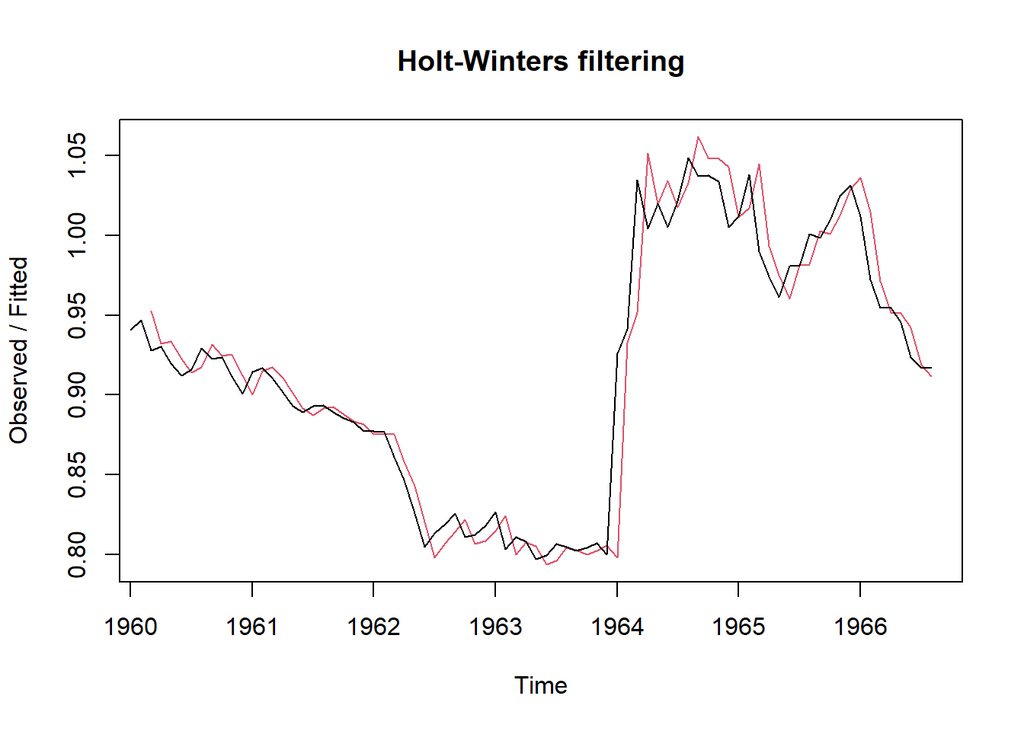

```r
plot(des.opt)
```

```r
#ramalan
ramalandesopt<- forecast(des.opt, h=20)
ramalandesopt
```

```
##          Point Forecast     Lo 80     Hi 80     Lo 95     Hi 95
## Sep 1966      0.9120119 0.8822059 0.9418179 0.8664275 0.9575962
## Oct 1966      0.9070549 0.8634316 0.9506783 0.8403387 0.9737711
## Nov 1966      0.9020980 0.8464057 0.9577903 0.8169240 0.9872720
## Dec 1966      0.8971410 0.8300618 0.9642203 0.7945522 0.9997299
## Jan 1967      0.8921841 0.8140028 0.9703654 0.7726162 1.0117520
## Feb 1967      0.8872272 0.7980363 0.9764180 0.7508215 1.0236328
## Mar 1967      0.8822702 0.7820551 0.9824853 0.7290045 1.0355359
## Apr 1967      0.8773133 0.7659949 0.9886317 0.7070665 1.0475601
## May 1967      0.8723563 0.7498144 0.9948982 0.6849446 1.0597680
## Jun 1967      0.8673994 0.7334868 1.0013120 0.6625977 1.0722010
## Jul 1967      0.8624424 0.7169938 1.0078911 0.6399979 1.0848870
## Aug 1967      0.8574855 0.7003230 1.0146479 0.6171263 1.0978447
## Sep 1967      0.8525285 0.6834662 1.0215909 0.5939700 1.1110871
## Oct 1967      0.8475716 0.6664176 1.0287256 0.5705205 1.1246227
## Nov 1967      0.8426146 0.6491736 1.0360557 0.5467721 1.1384572
## Dec 1967      0.8376577 0.6317319 1.0435835 0.5227214 1.1525940
## Jan 1968      0.8327008 0.6140914 1.0513101 0.4983666 1.1670349
## Feb 1968      0.8277438 0.5962516 1.0592360 0.4737071 1.1817805
## Mar 1968      0.8227869 0.5782127 1.0673610 0.4487430 1.1968307
## Apr 1968      0.8178299 0.5599753 1.0756845 0.4234753 1.2121845
```

Selanjutnya akan dilakukan perhitungan akurasi pada data latih maupun data uji dengan ukuran akurasi SSE, MSE dan MAPE.

#### Akurasi Data Latih

```r
#Akurasi Data Training
ssedes.train1<-des.1$SSE
msedes.train1<-ssedes.train1/length(train.ts)
sisaandes1<-ramalandes1$residuals
head(sisaandes1)
```

```
##              Jan         Feb         Mar         Apr         May         Jun
## 1960          NA          NA -0.02480000 -0.02264800 -0.03252048 -0.03651764
```

```r
mapedes.train1 <- sum(abs(sisaandes1[3:length(train.ts)]/train.ts[3:length(train.ts)])
                      *100)/length(train.ts)

akurasides.1 <- matrix(c(ssedes.train1,msedes.train1,mapedes.train1))
row.names(akurasides.1)<- c("SSE", "MSE", "MAPE")
colnames(akurasides.1) <- c("Akurasi lamda=0.2 dan gamma=0.2")
akurasides.1
```

```
##      Akurasi lamda=0.2 dan gamma=0.2
## SSE                      0.154283803
## MSE                      0.001928548
## MAPE                     2.942870868
```

```r
ssedes.train2<-des.2$SSE
msedes.train2<-ssedes.train2/length(train.ts)
sisaandes2<-ramalandes2$residuals
head(sisaandes2)
```

```
##              Jan         Feb         Mar         Apr         May         Jun
## 1960          NA          NA -0.02480000 -0.00925600 -0.01387232 -0.01062183
```

```r
mapedes.train2 <- sum(abs(sisaandes2[3:length(train.ts)]/train.ts[3:length(train.ts)])
                      *100)/length(train.ts)

akurasides.2 <- matrix(c(ssedes.train2,msedes.train2,mapedes.train2))
row.names(akurasides.2)<- c("SSE", "MSE", "MAPE")
colnames(akurasides.2) <- c("Akurasi lamda=0.6 dan gamma=0.3")
akurasides.2
```

```
##      Akurasi lamda=0.6 dan gamma=0.3
## SSE                     0.0507104685
## MSE                     0.0006338809
## MAPE                    1.7124943120
```

Hasil akurasi dari data latih didapatkan skenario 2 dengan lamda=0.6 dan gamma=0.3 memiliki hasil yang lebih baik. Namun untuk kedua skenario dapat dikategorikan peramalan sangat baik berdasarkan nilai MAPE-nya.

#### Akurasi Data Uji

```r
#Akurasi Data Testing
selisihdes1<-ramalandes1$mean-testing$Price
selisihdes1
```

```
##               Jan          Feb          Mar          Apr          May
## 1966
## 1967  0.029894788  0.026623470  0.038652153  0.001380836 -0.046190482
## 1968 -0.097261021 -0.109632338 -0.131903655 -0.145074973
##               Jun          Jul          Aug          Sep          Oct
## 1966                                         0.017580057  0.019308740
## 1967 -0.075561799 -0.078233116 -0.061004434 -0.054875751 -0.050647069
## 1968
##               Nov          Dec
## 1966  0.011637422  0.016466105
## 1967 -0.079318386 -0.073189703
## 1968
```

```r
SSEtestingdes1<-sum(selisihdes1^2)
MSEtestingdes1<-SSEtestingdes1/length(testing$Price)
MAPEtestingdes1<-sum(abs(selisihdes1/testing$Price)*100)/length(testing$Price)

selisihdes2<-ramalandes2$mean-testing$Price
selisihdes2
```

```
##               Jan          Feb          Mar          Apr          May
## 1966
## 1967  0.010009596  0.005731577  0.016753559 -0.021524460 -0.070102479
## 1968 -0.129226629 -0.142604648 -0.165882666 -0.180060685
##               Jun          Jul          Aug          Sep          Oct
## 1966                                         0.001721671  0.002443652
## 1967 -0.100480498 -0.104158516 -0.087936535 -0.082814554 -0.079592573
## 1968
##               Nov          Dec
## 1966 -0.006234366 -0.002412385
## 1967 -0.109270591 -0.104148610
## 1968
```

```r
SSEtestingdes2<-sum(selisihdes2^2)
MSEtestingdes2<-SSEtestingdes2/length(testing$Price)
MAPEtestingdes2<-sum(abs(selisihdes2/testing$Price)*100)/length(testing$Price)

selisihdesopt<-ramalandesopt$mean-testing$Price
selisihdesopt
```

```
##                Jan           Feb           Mar           Apr           May
## 1966
## 1967  0.0420840992  0.0431271541  0.0594702090  0.0265132639 -0.0167436812
## 1968 -0.0332992422 -0.0413561874 -0.0593131325 -0.0681700776
##                Jun           Jul           Aug           Sep           Oct
## 1966                                            0.0125118797  0.0185549346
## 1967 -0.0418006264 -0.0401575715 -0.0186145166 -0.0081714617  0.0003715931
## 1968
##                Nov           Dec
## 1966  0.0151979895  0.0243410444
## 1967 -0.0239853520 -0.0135422971
## 1968
```

```r
SSEtestingdesopt<-sum(selisihdesopt^2)
MSEtestingdesopt<-SSEtestingdesopt/length(testing$Price)
MAPEtestingdesopt<-sum(abs(selisihdesopt/testing$Price)*100)/length(testing$Price)

akurasitestingdes <-
  matrix(c(SSEtestingdes1,MSEtestingdes1,MAPEtestingdes1,SSEtestingdes2,MSEtestingdes2,
           MAPEtestingdes2,SSEtestingdesopt,MSEtestingdesopt,MAPEtestingdesopt),
         nrow=3,ncol=3)
row.names(akurasitestingdes)<- c("SSE", "MSE", "MAPE")
colnames(akurasitestingdes) <- c("des ske1","des ske2","des opt")
akurasitestingdes
```

```
##         des ske1    des ske2     des opt
## SSE  0.099020849 0.167477908 0.024991737
## MSE  0.004951042 0.008373895 0.001249587
## MAPE 6.663592016 8.135081616 3.490699693
```

Model dengan parameter λ = 0.6 dan γ = 0.3 (ske2) memberikan hasil terbaik pada data latih (MAPE = 1.71), namun buruk pada data uji (MAPE = 8.14).

Model dengan parameter λ = 0.2 dan γ = 0.2 (ske1) memiliki hasil sedang pada data latih (MAPE = 2.94) dan lebih baik dari ske2 di data uji (MAPE = 6.66).

Model hasil optimasi (DES opt) memberikan hasil terbaik di data uji (MAPE = 3.49) dan memiliki nilai SSE dan MSE terendah. Ini adalah model yang paling akurat, cocok untuk prediksi.

### Kesimpulan Akhir

Dalam analisis ini, dilakukan peramalan data harga kopi Arabika menggunakan tiga metode pemulusan: Double Moving Average (DMA), Single Exponential Smoothing (SES), dan Double Exponential Smoothing (DES). Setiap metode dievaluasi berdasarkan akurasi prediksinya pada data latih dan data uji, menggunakan metrik SSE, MSE, dan MAPE.

Hasil Evaluasi: